# M1: Discrete Step Metrics

Day 2 — Movement Metrics

Animal Movement Analyses for Ecologists | SYSU Shenzhen

## Learning Objectives

By the end of this module you will be able to:

1. Check each individual’s empirical GPS sampling rate with `summarize_sampling_rate()`, and use `track_resample()` to select which consecutive fixes count as a comparable step for a given analysis — recognizing that uneven sampling is the norm in animal tracking studies
2. Derive step length (`sl_`), turning angle (`ta_`), and time step (`dt_`) for every individual with `amt::steps_by_burst()`, scaling from one individual to all with the `nest()`/`map()`/`unnest()` pattern, and calculate speed from the resulting step table
3. Compute the same three quantities directly from a `move2` object with `mt_distance()`, `mt_speed()`, and `mt_turnangle()`/`mt_azimuth()`, and recognize when `amt`’s track/step infrastructure is worth the extra setup

**Packages used:** `amt`, `move2`, `sf`, `tidyverse`, `lubridate`, `units`

## Ecological context: what step-based metrics reveal

Step length, turning angle, and speed are the most basic movement metrics we can extract from GPS data—the displacement and directional change between one fix and the next. They may seem like a modest starting point, but nearly every higher‑level analysis depends on them. Speed distributions help separate resting from traveling bouts; turning‑angle patterns distinguish directed movement from area‑restricted search; and both feed directly into behavioral‑state models (HMMs), covered in a later module.

Even at this basic level, these metrics often carry ecological information. A sustained sequence of long, straight steps can indicate directed travel along a fence line or road, where movement is constrained by the landscape rather than driven by foraging. Similar patterns may also signal migratory transit. In contrast, short steps with high turning angles typically cluster in areas where animals are settled, foraging, or engaged in localized “ranging” movements outside a migration period.

Getting clean step‑based metrics requires comparing steps that span the *same* time interval. A step length calculated across a 20‑minute gap and one calculated across a 6‑hour gap are not measuring the same underlying process, and mixing them without accounting for the difference will distort every downstream metric — including the speed and turning‑angle distributions above. Section 2 walks through how to choose a consistent interval for the discrete, step‑based calculations used in this module.

That said, not all movement analyses require regular sampling intervals. Continuous‑time movement models — covered in another module on continuous-time movement modeling — are designed specifically to use irregular fix intervals, treating the gaps between fixes as informative rather than a nuisance.

## 1. Setup

Start by importing the necessary packages to conduct our analysis.

```r
# Clear R's memory
rm(list=ls())

# You may need to install these packages first
# install.packages(c("amt", "move2", "sf", "tidyverse", "lubridate", "units"))

library(amt)         # Tracks, resampling, step metrics
library(move2)       # move2 helpers (mt_distance, mt_speed, mt_turnangle, ...)
library(sf)          # Spatial vector data
library(tidyverse)   # Data wrangling and visualization
library(lubridate)   # Timestamps and durations
library(units)       # Explicit unit conversions
```

### 1.1 Reload/Recalculate `trk_all`

In the previous module, we built a multi-individual `amt` track from the cleaned `move2` data and reprojected it to a metric CRS — then set it aside for now. `trk_all` itself wasn’t saved to disk (only the cleaned `move2` object was), so as a reminder, here’s the exact code that built it:

```r
load("Data/WB_clean.rdata")  # loads WB.mv2, the cleaned wildebeest track data

latlong_crs <- "EPSG:4326"   # WGS84 geographic — what move2/Movebank gives us
utm_crs     <- "EPSG:32737"  # UTM Zone 37S — metric, appropriate for Athi-Kaputiei, Kenya
```

Rebuild the trk_all object

```r
WB_df <- WB.mv2 %>%
  mutate(x = sf::st_coordinates(.)[, 1],
         y = sf::st_coordinates(.)[, 2]) %>%
  as_tibble() %>%
  transmute(id = individual_local_identifier,
            x, y,
            t = timestamp,
            temp = external_temperature) %>%
  arrange(id, t)

trk_all <- make_track(WB_df, x, y, t, temp, id = id, crs = latlong_crs, lon = x, lat = y)
trk_all <- transform_coords(trk_all, utm_crs)

class(trk_all)        # track_xyt, track_xy, tbl_df, tbl, data.frame
```

```
## [1] "track_xyt"  "track_xy"   "tbl_df"     "tbl"        "data.frame"
```

```r
n_distinct(trk_all$id) # number of individuals
```

```
## [1] 12
```

## 2. Sampling design and choosing comparable steps

Before we run any `amt` function across all wildebeest, we need a way to apply a function that’s written for *one* track to every individual in `trk_all` at once. That’s what the `nest()` / `map()` / `unnest()` is for:

- **`nest(data = -id)`** collapses `trk_all` from “one row per fix” into “one row per individual.” Every column except `id` gets folded into a single list-column called `data` — so each row holds, in effect, one individual’s entire track as its own self-contained tibble. Run the chunk below and click on a `data` entry in the viewer to see this directly.
- **`map(data, FUN)`** then applies a function (`FUN`) to each of those per-individual tibbles in turn, one at a time, and collects the results back into a new list-column. This is the part that does the actual “scale from one individual to all” work — `FUN` itself (e.g., `summarize_sampling_rate()` below) only ever has to know how to handle a single track.
- **`unnest()`** reverses the first step: it flattens a list-column of results back out into an ordinary tibble, with `id` carried along on every resulting row so you always know which individual each value came from.

```r
trk_nested <- trk_all %>% nest(data = -id)
trk_nested # try view(trk_nested) to see the dataframe in a separate window
```

```
## # A tibble: 12 × 2
##    id        data
##    <fct>     <list>
##  1 Sotua     <trck_xyt [4,809 × 6]>
##  2 Laingoni  <trck_xyt [7,806 × 6]>
##  3 Ne Mpaash <trck_xyt [7,353 × 6]>
##  4 Noontare  <trck_xyt [11,095 × 6]>
##  5 Ole Nagol <trck_xyt [1,110 × 6]>
##  6 Kiranto   <trck_xyt [11,974 × 6]>
##  7 Paita     <trck_xyt [11,114 × 6]>
##  8 Karbolo   <trck_xyt [6,084 × 6]>
##  9 Ntishya   <trck_xyt [11,837 × 6]>
## 10 Peria     <trck_xyt [11,840 × 6]>
## 11 Sawani    <trck_xyt [3,586 × 6]>
## 12 Kikaya    <trck_xyt [10,769 × 6]>
```

### 2.1 Check the sampling rate per individual

```r
sampling_rates <- trk_nested %>%
  mutate(rate = map(data, summarize_sampling_rate)) %>% # noticed we used `map` function
  select(id, rate) %>%
  unnest(rate)

sampling_rates
```

```
## # A tibble: 12 × 10
##    id           min    q1 median  mean    q3   max    sd     n unit
##  * <fct>      <dbl> <dbl>  <dbl> <dbl> <dbl> <dbl> <dbl> <int> <chr>
##  1 Sotua     0.0167     1      1  1.66  2.88  201. 3.18   4808 hour
##  2 Laingoni  0.0167     1      1  1.60  2.98  211  2.84   7805 hour
##  3 Ne Mpaash 0.0167     1      1  1.56  2.93  212  2.84   7352 hour
##  4 Noontare  0.0167     1      1  1.68  2.98  227. 3.13  11094 hour
##  5 Ole Nagol 0.0667     1      1  1.50  2.93    4  0.872  1109 hour
##  6 Kiranto   0.0167     1      1  1.56  1.03  211  2.70  11973 hour
##  7 Paita     0.0167     1      1  1.58  2.02  211  2.99  11113 hour
##  8 Karbolo   0.0167     1      1  1.64  2.95  193. 3.19   6083 hour
##  9 Ntishya   0.0167     1      1  1.55  2      91  1.96  11836 hour
## 10 Peria     0.0667     1      1  1.57  2.93  357  3.71  11839 hour
## 11 Sawani    0.0667     1      1  1.58  2.02  223. 3.90   3585 hour
## 12 Kikaya    0.0167     1      1  1.62  2.97  217  3.05  10768 hour
```

> **What this shows for this dataset:** `summarize_sampling_rate()` returns the distribution (min, median, mean, max, etc.) of the time gap between consecutive fixes for one individual. The collars deployed on the animals were programmed with two different fix rates by design: hourly during the day and every three hours at night to save battery without sacrificing resolution during the period of greatest activity.

> Even when the collared were programmed to sample locations regularly, the real data will still likely show variations in temporal intervals. Duty-cycled collars, missed fixes, and satellite-visibility gaps all produce a mix of intervals in almost any real deployment.

### 2.2 Picking comparable steps with `track_resample()`

Step length, turning angle, and speed are only comparable across steps if every step spans roughly the same time interval — a step computed over 1 hour and one computed over 3 hours describe different things, even though both are perfectly valid fixes from the same deliberate duty cycle. `track_resample()` lets us state explicitly which consecutive fixes should count as a step for the analysis at hand.

Here, we target the daytime’s nominal 1-hour rate, with a 15-minute tolerance to absorb ordinary GPS jitter without stitching genuinely separate fixes together into a false step:

```r
trk_resampled <- trk_nested %>%
  mutate(resampled = map(data, ~ track_resample(.x, rate = hours(1), tolerance = minutes(15)))) %>%
  select(id, resampled) %>%
  unnest(resampled)

head(trk_resampled)
```

```
## # A tibble: 6 × 8
##   id         x_       y_ t_                  temp   lon   lat burst_
## * <fct>   <dbl>    <dbl> <dttm>              [°C] <dbl> <dbl>  <dbl>
## 1 Sotua 260296. 9849694. 2010-10-15 13:00:00   29  36.8 -1.36      1
## 2 Sotua 260329. 9849518. 2010-10-15 14:00:00   28  36.8 -1.36      1
## 3 Sotua 260393. 9849505. 2010-10-15 15:00:00   25  36.8 -1.36      1
## 4 Sotua 260432. 9849416. 2010-10-15 18:00:00   21  36.8 -1.36      2
## 5 Sotua 260499. 9849319. 2010-10-15 21:00:00   18  36.8 -1.36      3
## 6 Sotua 260365. 9849360. 2010-10-16 00:00:00   18  36.8 -1.36      4
```

> **Note:** `track_resample()` adds a `burst_` column, but it does not delete every fix that falls outside the target rate the way “resample” might suggest. Internally it walks the timestamps against `rate ± tolerance`, relative to whichever fix is currently anchoring the burst: a fix that arrives *too soon* is dropped from the returned track entirely; a fix that arrives *inside* the tolerance window continues the current burst; and a fix that arrives *late* is **kept, not deleted** — it simply starts a new `burst_` number. With `rate = hours(1)`, the daytime’s roughly-hourly fixes form long, usable bursts, while the night’s ~3-hour gaps exceed the 15-minute tolerance and each night fix becomes the start of its own new burst. `steps_by_burst()` then only computes a step within a burst, so no step is silently computed across the day/night gap — but the location itself is retained in the data.

> This burst-tagging is enough on its own if everything downstream also runs in `amt` (`steps_by_burst()` respects `burst_` automatically). It is **not** the same thing as inserting `NA` at every missing regular timestamp, which is what “regularizing” means for some packages outside `amt`.

### 2.3 An alternative: one shared 3-hour interval

If the goal is a single, consistent step length across the *whole* diel cycle rather than daytime resolution, target the night’s native rate instead. This keeps roughly one fix every 3 hours and drops the extra daytime fixes in between, so every resulting step — day or night — spans the same nominal interval:

```r
trk_resampled_3h <- trk_nested |>
  mutate(resampled = map(data, function(x)
    x |> track_resample(rate = hours(3), tolerance = minutes(15)))) |>
  select(id, resampled) |>
  unnest(resampled) |>
  # The track_resample function doesn't seem to be working properly.  Using this working around:
  mutate(hour = hour(t_)) |>
  filter(hour %in% c(0,3,6,9,12,15,18,21)) |>
  select(!hour)

# trk_resampled_3h$hour <- hour(trk_resampled_3h$t_)
# plot(trk_resampled_3h$hour)

head(trk_resampled_3h)
```

```
## # A tibble: 6 × 8
##   id         x_       y_ t_                  temp   lon   lat burst_
## * <fct>   <dbl>    <dbl> <dttm>              [°C] <dbl> <dbl>  <dbl>
## 1 Sotua 260432. 9849416. 2010-10-15 18:00:00   21  36.8 -1.36      2
## 2 Sotua 260499. 9849319. 2010-10-15 21:00:00   18  36.8 -1.36      2
## 3 Sotua 260365. 9849360. 2010-10-16 00:00:00   18  36.8 -1.36      2
## 4 Sotua 260066. 9849895. 2010-10-16 03:00:00   17  36.8 -1.36      2
## 5 Sotua 259962. 9849750. 2010-10-16 06:00:00   23  36.8 -1.36      2
## 6 Sotua 260149. 9849651. 2010-10-16 09:00:00   28  36.8 -1.36      2
```

> **Note:** The hourly version in 2.2 resolves fine-scale daytime behavior at the cost of treating night locations will not form effective steps as they are treated as differnet bursts. This 3-hour version provides an “apples-to-apples” step length across the full cycle at the cost of discarding extra daytime fixes that were collected at a higher resolution. The rest of this module continues with the hourly (`trk_resampled`) version, since Section 3’s goal is to demonstrate the step-metric workflow at the finer of the two resolutions — substitute `trk_resampled_3h` in Section 3 if whole-cycle comparability matters more for your question.

This same regular 3-hour dataset is useful well beyond this module — anything downstream that wants one comparable time interval across the full day/night cycle can reuse it directly rather than re-deriving it from scratch. We save it here once so later modules can just load it:

```r
save(trk_resampled_3h, file = "Data/WB_3h_resampled.rdata")
```

## 3. Step metrics with `amt::steps_by_burst()`

`sl_` is step length (meters, since `trk_all` is in a metric CRS), `ta_` is turning angle (radians), and `dt_` is the time step between the two fixes that make up the step.

### 3.1 One individual, step-by-step

Calculate steps for a single individual.

```r
one_trk <- trk_resampled %>% filter(id == "Sotua")

one_steps <- steps_by_burst(one_trk)
head(one_steps)
```

```
## # A tibble: 6 × 11
##   burst_     x1_     x2_      y1_      y2_   sl_ direction_p    ta_
## *  <dbl>   <dbl>   <dbl>    <dbl>    <dbl> <dbl>       <dbl>  <dbl>
## 1      1 260296. 260329. 9849694. 9849518. 179.       -1.38  NA
## 2      1 260329. 260393. 9849518. 9849505.  65.1      -0.201  1.18
## 3      5 260066. 259959. 9849895. 9849984. 139.        2.44  NA
## 4      5 259959. 259885. 9849984. 9849813. 186.       -1.98   1.86
## 5      5 259885. 259962. 9849813. 9849750.  99.4      -0.696  1.28
## 6      5 259962. 260068. 9849750. 9849735. 107.       -0.139  0.557
## # ℹ 3 more variables: t1_ <dttm>, t2_ <dttm>, dt_ <drtn>
```

### 3.2 Deriving speed

`steps_by_burst()` doesn’t return speed directly — we calculate it as step length divided by time step:

```r
one_steps <- one_steps %>%
  mutate(dt_s = as.numeric(dt_, units = "secs"),
         speed_m_s = sl_ / dt_s)

head(one_steps)
```

```
## # A tibble: 6 × 13
##   burst_     x1_     x2_      y1_      y2_   sl_ direction_p    ta_
## *  <dbl>   <dbl>   <dbl>    <dbl>    <dbl> <dbl>       <dbl>  <dbl>
## 1      1 260296. 260329. 9849694. 9849518. 179.       -1.38  NA
## 2      1 260329. 260393. 9849518. 9849505.  65.1      -0.201  1.18
## 3      5 260066. 259959. 9849895. 9849984. 139.        2.44  NA
## 4      5 259959. 259885. 9849984. 9849813. 186.       -1.98   1.86
## 5      5 259885. 259962. 9849813. 9849750.  99.4      -0.696  1.28
## 6      5 259962. 260068. 9849750. 9849735. 107.       -0.139  0.557
## # ℹ 5 more variables: t1_ <dttm>, t2_ <dttm>, dt_ <drtn>, dt_s <dbl>,
## #   speed_m_s <dbl>
```

### 3.3 Scaling to all individuals

Now take the code above and scale it to all individuals by using the `map()` function.

```r
trk_resampled_nested <- trk_resampled %>% nest(data = -id)

wb_steps <- trk_resampled_nested %>%
  mutate(steps = map(data, steps_by_burst)) %>%
  select(id, steps) %>%
  unnest(steps) %>%
  mutate(dt_s = as.numeric(dt_, units = "secs"),
         speed_m_s = sl_ / dt_s)

head(wb_steps)
```

```
## # A tibble: 6 × 14
##   id    burst_     x1_     x2_      y1_      y2_   sl_ direction_p    ta_
## * <fct>  <dbl>   <dbl>   <dbl>    <dbl>    <dbl> <dbl>       <dbl>  <dbl>
## 1 Sotua      1 260296. 260329. 9849694. 9849518. 179.       -1.38  NA
## 2 Sotua      1 260329. 260393. 9849518. 9849505.  65.1      -0.201  1.18
## 3 Sotua      5 260066. 259959. 9849895. 9849984. 139.        2.44  NA
## 4 Sotua      5 259959. 259885. 9849984. 9849813. 186.       -1.98   1.86
## 5 Sotua      5 259885. 259962. 9849813. 9849750.  99.4      -0.696  1.28
## 6 Sotua      5 259962. 260068. 9849750. 9849735. 107.       -0.139  0.557
## # ℹ 5 more variables: t1_ <dttm>, t2_ <dttm>, dt_ <drtn>, dt_s <dbl>,
## #   speed_m_s <dbl>
```

### 3.4 Visualizing the distributions

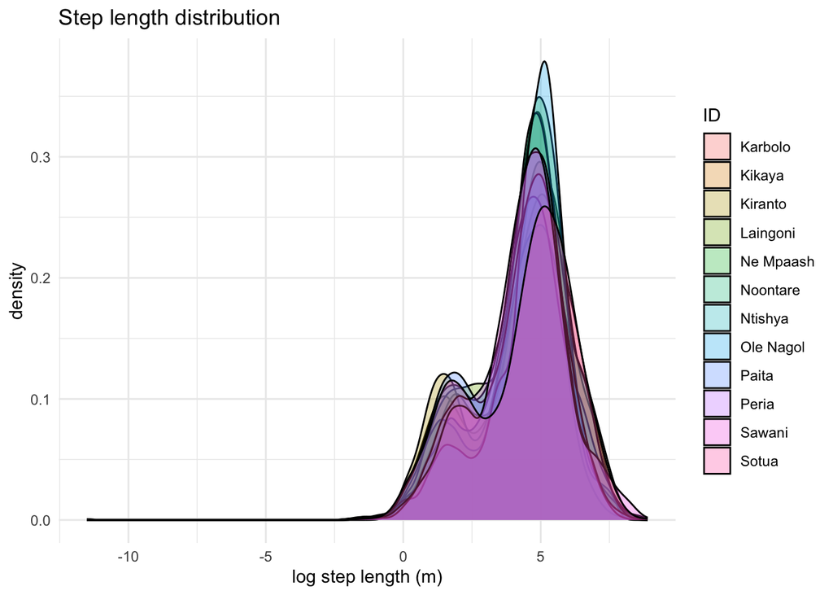

```r
wb_steps %>%
  ggplot(aes(x = log(sl_ + 0.00001), fill = factor(id))) +
  geom_density(alpha = 0.3) +
  theme_minimal() +
  labs(x = "log step length (m)", fill = "ID", title = "Step length distribution")
```

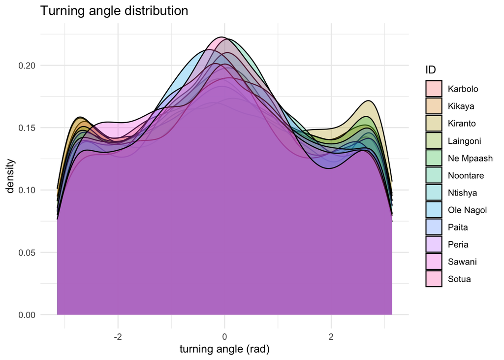

```r
wb_steps %>%
  ggplot(aes(x = ta_, fill = factor(id))) +
  geom_density(alpha = 0.3) +
  theme_minimal() +
  labs(x = "turning angle (rad)", fill = "ID", title = "Turning angle distribution")
```

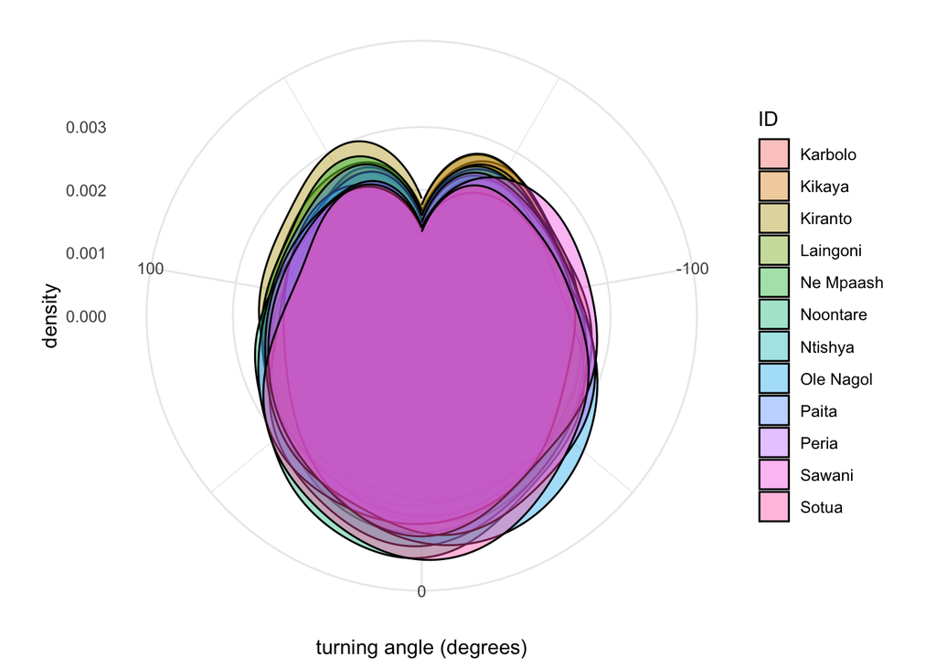

```r
wb_steps %>%
  mutate(ta_deg = ta_ * 180 / pi) %>%
  filter(!is.na(ta_deg)) %>%
  ggplot(aes(x = ta_deg, fill = factor(id))) +
  geom_density(alpha = 0.4) +
  coord_polar() +
  theme_minimal() +
  labs(x = "turning angle (degrees)", fill = "ID")
```

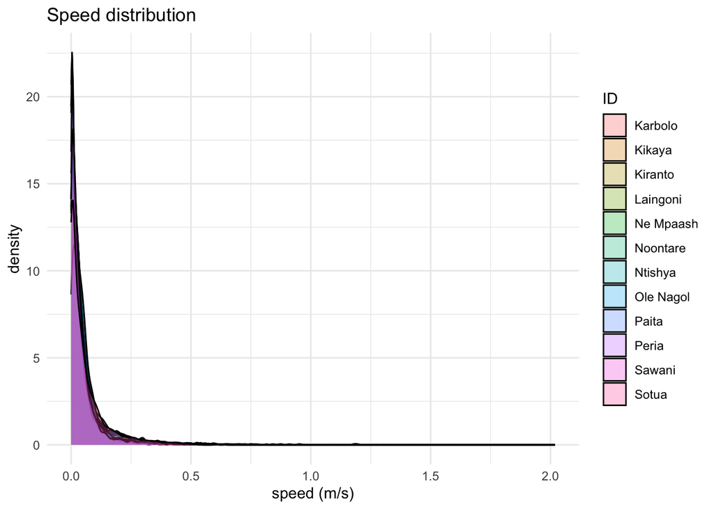

```r
wb_steps %>%
  ggplot(aes(x = speed_m_s, fill = factor(id))) +
  geom_density(alpha = 0.3) +
  theme_minimal() +
  labs(x = "speed (m/s)", fill = "ID", title = "Speed distribution")
```

> **Discussion:** A long right tail in step length or speed often reflects a handful of directed, fast-moving steps rather than typical movement. Can you see individual differences from the current figure? How could you improve the figure?

## 4. Quick look: the same basics directly from `move2`

`amt`’s track/step machinery is the most flexible route to these metrics — it’s what supports the resampling control above and the windowed home-range/trait calculations covered in a later module. But for a fast look at step length, speed, and turning angle, `move2` computes them directly on the cleaned `move2` object, no track conversion required:

```r
WB_metric <- WB.mv2 %>%
  st_transform(utm_crs) %>%
  mutate(step_length_m = mt_distance(., units = "m"),
         speed_m_s     = mt_speed(., units = "m/s"))

WB_metric %>%
  st_drop_geometry() %>%
  select(individual_local_identifier, timestamp, step_length_m, speed_m_s) %>%
  head()
```

```
## A <move2> with `track_id_column` "individual_local_identifier" and
## `time_column` "timestamp"
## Containing 1 track lasting 7 hours in a
## # A tibble: 6 × 4
##   individual_local_identifier timestamp           step_length_m speed_m_s
## * <fct>                       <dttm>                        [m]     [m/s]
## 1 Karbolo                     2010-10-19 00:00:00        704.    0.0652
## 2 Karbolo                     2010-10-19 03:00:00        490.    0.136
## 3 Karbolo                     2010-10-19 04:00:00         84.3   0.0234
## 4 Karbolo                     2010-10-19 05:00:00         16.4   0.00456
## 5 Karbolo                     2010-10-19 06:00:00        536.    0.149
## 6 Karbolo                     2010-10-19 07:00:00          2.20  0.000611
## Track features:
## # A tibble: 1 × 54
##   deployment_id     tag_id individual_id animal_life_stage attachment_type
##         <int64>    <int64>       <int64> <fct>             <fct>
## 1    3568311114 3568311081    3568311001 8 years           collar
## # ℹ 49 more variables: deploy_off_timestamp <dttm>, deploy_on_timestamp <dttm>,
## #   deployment_end_comments <chr>, duty_cycle <chr>,
## #   deployment_local_identifier <fct>, study_site <chr>, sensor_type_ids <chr>,
## #   capture_location <POINT [°]>, deploy_on_location <POINT [°]>,
## #   deploy_off_location <POINT [°]>, death_comments <chr>,
## #   individual_local_identifier <fct>, sex <fct>, taxon_canonical_name <fct>,
## #   individual_number_of_deployments <int>, mortality_location <POINT [°]>, …
```

```r
WB_angles <- WB.mv2 %>%
  st_transform(latlong_crs) %>%   # mt_turnangle()/mt_azimuth() are only implemented for geographic coordinates
  mutate(turn_angle = mt_turnangle(.),
         heading     = mt_azimuth(.))

WB_angles %>%
  st_drop_geometry() %>%
  select(individual_local_identifier, timestamp, turn_angle, heading) %>%
  head()
```

```
## A <move2> with `track_id_column` "individual_local_identifier" and
## `time_column` "timestamp"
## Containing 1 track lasting 7 hours in a
## # A tibble: 6 × 4
##   individual_local_identifier timestamp           turn_angle heading
## * <fct>                       <dttm>                   [rad]   [rad]
## 1 Karbolo                     2010-10-19 00:00:00     NA      0.696
## 2 Karbolo                     2010-10-19 03:00:00      0.456  1.15
## 3 Karbolo                     2010-10-19 04:00:00      2.54  -2.59
## 4 Karbolo                     2010-10-19 05:00:00     -0.938  2.75
## 5 Karbolo                     2010-10-19 06:00:00      1.16  -2.37
## 6 Karbolo                     2010-10-19 07:00:00      2.46   0.0862
## Track features:
## # A tibble: 1 × 54
##   deployment_id     tag_id individual_id animal_life_stage attachment_type
##         <int64>    <int64>       <int64> <fct>             <fct>
## 1    3568311114 3568311081    3568311001 8 years           collar
## # ℹ 49 more variables: deploy_off_timestamp <dttm>, deploy_on_timestamp <dttm>,
## #   deployment_end_comments <chr>, duty_cycle <chr>,
## #   deployment_local_identifier <fct>, study_site <chr>, sensor_type_ids <chr>,
## #   capture_location <POINT [°]>, deploy_on_location <POINT [°]>,
## #   deploy_off_location <POINT [°]>, death_comments <chr>,
## #   individual_local_identifier <fct>, sex <fct>, taxon_canonical_name <fct>,
## #   individual_number_of_deployments <int>, mortality_location <POINT [°]>, …
```

> **Note:** `move2`’s angle functions currently only work on geographic (lon/lat) coordinates — reproject to `EPSG:4326` before calling them, and back to a metric CRS for anything distance-based (move2 package documentation, `mt_azimuth()` reference).

> **Why two routes to the same numbers?** `move2`’s `mt_*()` functions are vectorized across the whole multi-individual object directly — no `nest()`/`map()` needed, because they’re track-ID-aware internally. That’s simpler when all you want is step length, speed, or turning angle. `amt`’s track/step framework takes more setup, but that setup is what buys you controlled resampling (Section 2), and the burst- and window-aware metrics — displacement, intensity of use, home ranges — that later modules build on. Use whichever matches what you actually need.

## Practice: Apply to your own data

Please do the following:

1. **Check the sampling rate** for 2–3 individuals in your own dataset with `summarize_sampling_rate()`. Is it one consistent rate or does the sampling rate change similar to the wildebeest day/night schedule?
2. **Pick a target rate for `track_resample()`** that matches the question you’re asking — choose a finer rate of sampling if you want within-regime resolution or the coarser shared rate (as in Section 2.3) if you want one consistent interval across regimes — with a tolerance that reflects how much jitter your collars typically show.
3. **Compute step length, turning angle, and speed** with `steps_by_burst()`, scaling to all your individuals with the `nest()`/`map()`/`unnest()` pattern.
4. **Plot the distributions** and connect what you see back to your species’ ecology. Do long, directed steps line up with anything in the landscape (roads, fences, water points)? Do individuals differ in ways that match known differences (sex, age, season)?

**Useful questions to answer for your own dataset:**

- Does your species/dataset have a known duty cycle (e.g., different day vs. night fix rates, or a schedule change partway through deployment)? If so, treat the sampling rate as part of the sampling design to work with, not noise to remove.
- Are there individuals with unusually short bursts after resampling — a sign of poor satellite visibility or frequent missed fixes, as opposed to a designed schedule?
- Do your step-length or speed distributions have a long right tail. If yes, what’s producing this tail?
- Do your research question(s) require a regular interval, or would an irregularity-aware approach (e.g., continuous-time movement models, covered in a related module) fit better?

## Key functions reference

| Function | Package | Purpose |
| --- | --- | --- |
| `summarize_sampling_rate()` | `amt` | Summarize the time-gap distribution between consecutive fixes for one track |
| `track_resample()` | `amt` | Select fixes onto a chosen nominal time interval within a tolerance, tagging `burst_` membership |
| `steps_by_burst()` | `amt` | Compute step length (`sl_`), turning angle (`ta_`), and time step (`dt_`) within each burst |
| `nest()` / `map()` / `unnest()` | `tidyr` / `purrr` | Apply a single-track `amt` function across all individuals |
| `mt_distance()` | `move2` | Step (point-to-point) distance directly on a `move2` object |
| `mt_speed()` | `move2` | Step speed directly on a `move2` object |
| `mt_turnangle()` | `move2` | Relative turning angle between consecutive segments (geographic CRS only) |
| `mt_azimuth()` | `move2` | Heading/azimuth of each segment (geographic CRS only) |
| `save()` / `load()` | `base` | Export the 3-hour resampled track to `Data/` so later modules can reuse it instead of recomputing it |

*Next: **Module 2 — Summary Movement Traits** — having quantified step-by-step movement, we zoom out to individual-level summary traits over longer windows: displacement, maximum displacement, and diurnality — part of the same set of metrics used by the MoveTraits database to compare movement behavior across species.*